# Chapter 6: Monte Carlo Integration

Monte Carlo integration is a statistical method based on random sampling in order to approximate integrals. This section could alternatively be titled,

> “Integrals are hard, how can we avoid doing them?”

[figure not shown]

https://xkcd.com/2117/

# 1 A Tale of Two Approaches

Consider a one-dimensional integral.

The value of the integral can be derived analytically only for a few functions, $f$. For the rest, numerical approximations are often useful.

**Why is integration important to statistics?**

## 1.1 Numerical Integration

**Idea:** Approximate $\int_a^bf(x) dx$ via the sum of many polygons under the curve $f(x)$.

To do this, we could partition the interval $[a, b]$ into $m$ subintervals $[x_i, x_{i+1}]$ for $i = 0, \dots, m - 1$ with $x_0 = a$ and $x_m = b$.

Within each interval, insert $k + 1$ nodes, so for $[x_i, x_{i+1}]$ let $x^*_{ij}$ for $j = 0, \dots, k$, then
$$\int\limits_a^b f(x)dx = \sum\limits_{i = 0}^{m - 1}\int\limits_{x_i}^{x_{i + 1}} f(x) dx \approx \sum\limits_{i = 0}^{m - 1}\sum\limits_{j = 0}^{k}A_{ij}f(x_{ij}^*)$$
for some set of constants, $A_{ij}$.

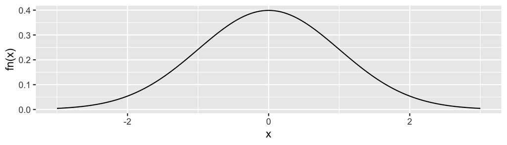

## 1.2 Monte Carlo Integration

How do we compute the mean of a distribution?

**Example 1.1** Let $X \sim Unif(0,1)$ and $Y \sim Unif(10, 20)$.

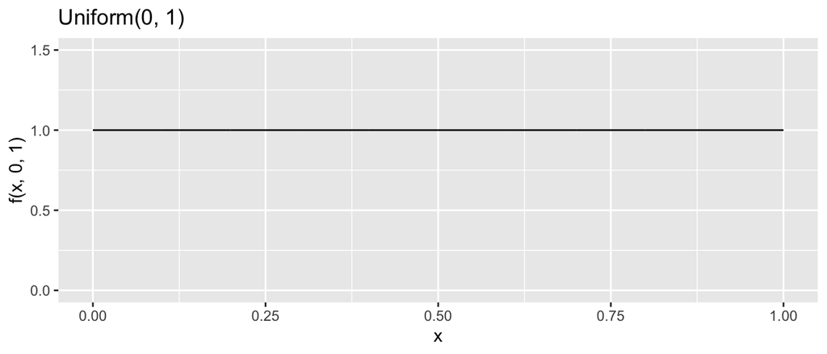

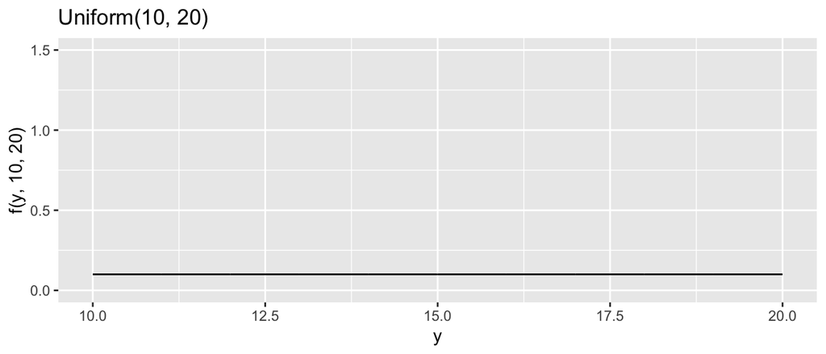

```r
x <- seq(0, 1, length.out = 1000)
f <- function(x, a, b) 1/(b - a)
ggplot() +
  geom_line(aes(x, f(x, 0, 1))) +
  ylim(c(0, 1.5)) +
  ggtitle("Uniform(0, 1)")

y <- seq(10, 20, length.out = 1000)
ggplot() +
  geom_line(aes(y, f(y, 10, 20))) +
  ylim(c(0, 1.5)) +
  ggtitle("Uniform(10, 20)")
```

Theory

### 1.2.1 Notation

$\theta$

$\hat{\theta}$

Distribution of $\hat{\theta}$

$E[\hat{\theta}]$

$Var(\hat{\theta})$

$\hat{E}[{\hat{\theta}}]$

$\hat{Var}({\hat{\theta}})$

$se(\hat{\theta})$

$\hat{se}(\hat{\theta})$

### 1.2.2 Monte Carlo Simulation

What is Monte Carlo simulation?

### 1.2.3 Monte Carlo Integration

Now consider $E[g(X)]$.

$$\theta = E[g(X)] = \int\limits_{-\infty}^{\infty}g(x)f(x) dx.$$

**Definition 1.1** *Monte Carlo integration* is the statistical estimation of the value of an integral using evaluations of an integrand at a set of points drawn randomly from a distirbution with support over the range of integration.

**Example 1.3**

Why the mean?

**Example 1.4** Let $v(x) = (g(x) - \theta)^2$, where $\theta = E[g(X)]$, and assume $g(X)^2$ has finite expectation under $f$. Then
$$Var(g(X)) = E[(g(X) - \theta)^2] = E[v(X)].$$
We can estimate this using a Monte Carlo approach.

Monte Carlo integration provides slow convergence, i.e. even though by the SLLN we know we have convergence, it may take us a while to get there.

But, Monte Carlo integration is a **very** powerful tool. While numerical integration methods are difficult to extend to multiple dimensions and work best with a smooth integrand, Monte Carlo does not suffer these weaknesses.

### 1.2.4 Algorithm

The approach to finding a Monte Carlo estimator for $\int g(x)f(x) dx$ is as follows.

**Example 1.5** Estimate $\theta = \int_0^1 h(x) dx$.

**Example 1.6** Estimate $\theta = \int_a^b h(x) dx$.

Another approach:

**Example 1.7** Monte Carlo integration for the standard Normal cdf. Let $X \sim N(0, 1)$, then the pdf of $X$ is
$$\phi(x) = f(x) = \frac{1}{\sqrt{2\pi}}\exp\left(-\frac{x^2}{2}\right), \qquad -\infty < x < \infty$$
and the cdf of $X$ is
$$\Phi(x) = F(x) = \int\limits_{-\infty}^x \frac{1}{\sqrt{2\pi}}\exp\left(-\frac{t^2}{2}\right)dt.$$
We will look at 3 methods to estimate $\Phi(x)$ for $x > 0$.

### 1.2.5 Inference for MC Estimators

But we need to estimate $Var(\hat{\theta})$.

So, if $m \uparrow$ then $Var(\hat{\theta}) \downarrow$. How much does changing $m$ matter?

**Example 1.8** If the current $se(\hat{\theta}) = 0.01$ based on $m$ samples, how many more samples do we need to get $se(\hat{\theta}) = 0.0001$?

Is there a better way to decrease the variance? **Yes!**

# 2 Importance Sampling

Can we do better than the simple Monte Carlo estimator of
$$\theta = E[g(X)] = \int g(x) f(x) dx \approx \frac{1}{m} \sum\limits_{i = 1}^m g(X_i)$$
where the variables $X_1, \dots, X_m$ are randomly sampled from $f$?

**Yes!!**

Goal: estimate integrals with lower variance than the simplest Monte Carlo approach.

To accomplish this, we will use *importance sampling*.

## 2.1 The Problem

If we are sampling an event that doesn’t occur frequently, then the naive Monte Carlo estimator will have high variance.

**Example 2.1** Monte Carlo integration for the standard Normal cdf. Consider estimating $\Phi(-3)$ or $\Phi(3)$.

We want to improve accuracy by causing rare events to occur more frequently than they would under the naive Monte Carlo sampling framework, thereby enabling more precise estimation.

## 2.2 Algorithm

Consider a density function $f(x)$ with support $\mathcal{X}$. Consider the expectation of $g(X)$,
$$\theta = E[g(X)] = \int_{\mathcal{X}}g(x)f(x)dx.$$
Let $\phi(x)$ be a density where $\phi(x) > 0$ for all $x \in \mathcal{X}$. Then the above statement can be rewritten as

An estimator of $\phi$ is given by the *importance sampling algorithm*:

**Example 2.2** Suppose you have a fair six-sided die. We want to estimate the probability that a single die roll will yield a $1$.

## 2.3 Choosing $\phi$

In order for the estimators to avoid excessive variability, it is important that $f(x)/\phi(x)$ is bounded and that $\phi$ has heavier tails than $f$.

**Example 2.3**

**Example 2.4**

A rare draw from $\phi$ with much higher density under $f$ than under $\phi$ will receive a huge weight and inflate the variance of the estimate.

Strategy –

**Example 2.5**

The importance sampling estimator can be shown to converge to $\theta$ under the SLLN so long as the support of $\phi$ includes all of the support of $f$.

## 2.4 Compare to Previous Monte Carlo Approach

Common goal –

**Step 1** Do some derivations.

1. Find an appropriate $f$ and $g$ to rewrite your integral as an expected value.
2. For **importance sampling** only,

   Find an appropriate $\phi$ to rewrite $\theta$ as an expectation with respect to $\phi$.

**Step 2** Write pseudo-code (a plan) to define estimator and set-up the algorithm.

- For **Monte Carlo integration**
- For **importance sampling**

**Step 3** Program it.

## 2.5 Extended Example

In this example, we will estimate $\theta = \int_0^1 \frac{e^{-x}}{1 + x^2} dx$ using MC integration and importance sampling with two different importance sampling distributions, $\phi$.

**Your Turn**

We want to use the following distribution for inference, where we know the shape, but not the full distributional form.

$$f(x) = c\frac{\log(x)}{1 + x^2}, \quad x \in [1, \pi]$$
What do we need for this to be a valid pdf?